# Analysis of human data

Marieke Jones, PhD

2022-11-02

# Set up

Load libraries

```r
library(tidyverse)
library(purrr)
library(stringr)
library(readxl)
library(lme4)
library(lmerTest)
library(modelr)
library(zoo)
library(ggeffects)
library(emmeans)

library(splines)
```

# Analysis Goals:

1. Is there a difference in length of the axon initial segment between AD and non-AD neurons? Is the length affected by the presence of tangles?
2. What does the TRIM46 fluorescence look like across the axon initial segment for AD v. non-AD neurons? Is the shape influenced by presence of tangles?
3. Does mean AIS intensity at each distance differ between AD and non-AD neurons? Is the mean AIS intensity impacted by the presence of a tangle?
4. Is the maximum AIS intensity for each neuron different between AD and non-AD brains? Is the maximum AIS intensity affected by the presence of tangles?
5. Is the minimum AIS intensity for each neuron different between AD and non-AD brains? Is the minimum AIS intensity affected by the presence of tangles?
6. Within Alzheimer’s brains, is there a difference in AIS length across severity of disease?
7. Within Alzheimer’s brains, is there a difference in AIS intensity across severity of disease?
1. Splines
2. Mean
3. Max

# Load and clean the data sets for each brain

Each brain’s data is stored in a separate file where the first column is the distance from the start of the axon initial segment and the other columns are the fluorescence intensity of TRIM46 (protein present in axon initial segment that is important for brain function) in a given neuron.

Write a function that will read the file and clean it

```r
readclean <- function(filename){
  dat <- read_excel(paste0("Data/Human/5D - Mean Concentration _ 5E - AIS Length/", filename), skip = 1) %>%
  dplyr::select(-avg, -std, -count, - `std rror`) %>%
  mutate(filename = filename) %>%
  pivot_longer(cols = contains("Neur"), names_to = "Neuron", values_to = "TRIM46_intensity")
}
```

Create a list of all of the datafiles and then iterate through them to read them all in.

```r
my_files <- list.files(path = "Data/Human/5D - Mean Concentration _ 5E - AIS Length/")

dfs <- map(my_files, ~readclean(.))
alldat <- bind_rows(dfs)

alldat
```

```
## # A tibble: 101,945 × 4
##    `Distance_(microns)` filename                    Neuron    TRIM46_intensity
##                   <dbl> <chr>                       <chr>                <dbl>
##  1                    0 5D 5E - AD 1 = A16-109.xlsx Neuron 1              144.
##  2                    0 5D 5E - AD 1 = A16-109.xlsx Neuron 2              160
##  3                    0 5D 5E - AD 1 = A16-109.xlsx Neuron 3              144
##  4                    0 5D 5E - AD 1 = A16-109.xlsx Neuron 4              161
##  5                    0 5D 5E - AD 1 = A16-109.xlsx Neuron 5              139.
##  6                    0 5D 5E - AD 1 = A16-109.xlsx Neuron 6              133
##  7                    0 5D 5E - AD 1 = A16-109.xlsx Neuron 7              138
##  8                    0 5D 5E - AD 1 = A16-109.xlsx Neuron 8              144
##  9                    0 5D 5E - AD 1 = A16-109.xlsx Neuron 9              172
## 10                    0 5D 5E - AD 1 = A16-109.xlsx Neuron 10             142.
## # … with 101,935 more rows
```

### Clean resulting dataset

Create two new columns to denote Status and Brain

```r
alldat <- alldat %>%
  separate(filename, into = c(NA, "filename"), sep = " - ") %>%
  separate(filename, into = c("Status", "Brain"), sep = " = ") %>%
  separate(Status, into = c("Status", NA), sep = " ") %>%
  separate(Brain, into = c("Brain", NA), sep = "\\.")

alldat
```

```
## # A tibble: 101,945 × 5
##    `Distance_(microns)` Status Brain   Neuron    TRIM46_intensity
##                   <dbl> <chr>  <chr>   <chr>                <dbl>
##  1                    0 AD     A16-109 Neuron 1              144.
##  2                    0 AD     A16-109 Neuron 2              160
##  3                    0 AD     A16-109 Neuron 3              144
##  4                    0 AD     A16-109 Neuron 4              161
##  5                    0 AD     A16-109 Neuron 5              139.
##  6                    0 AD     A16-109 Neuron 6              133
##  7                    0 AD     A16-109 Neuron 7              138
##  8                    0 AD     A16-109 Neuron 8              144
##  9                    0 AD     A16-109 Neuron 9              172
## 10                    0 AD     A16-109 Neuron 10             142.
## # … with 101,935 more rows
```

Rename Distance column

```r
alldat <- alldat %>%
  rename(Dist = `Distance_(microns)`)
```

Remove rows where TRIM46 Intensity is missing since those neurons where not that long.

```r
alldat <- alldat %>%
  arrange(Brain, Neuron, Dist) %>%
  drop_na(TRIM46_intensity)
```

Create new column that designates whether or not Neuron has a tangle or tau accumulation

```r
alldat %>% count(Brain, Neuron) #1160 unique neurons
```

```
## # A tibble: 1,160 × 3
##    Brain  Neuron                n
##    <chr>  <chr>             <int>
##  1 A11-30 Neuron 1 (tang)      14
##  2 A11-30 Neuron 10            11
##  3 A11-30 Neuron 100           25
##  4 A11-30 Neuron 101           30
##  5 A11-30 Neuron 102 (ta)      19
##  6 A11-30 Neuron 103 (tang)    12
##  7 A11-30 Neuron 104 (ta)      21
##  8 A11-30 Neuron 105 (ta)      19
##  9 A11-30 Neuron 106           12
## 10 A11-30 Neuron 107 (tang)    13
## # … with 1,150 more rows
```

```r
alldat %>% count(Brain, Neuron) %>% arrange(-n)
```

```
## # A tibble: 1,160 × 3
##    Brain    Neuron              n
##    <chr>    <chr>           <int>
##  1 A14-3    Neuron 101         89
##  2 A16-109  Neuron 33          72
##  3 A15-167_ Neuron 6           71
##  4 A14-3    Neuron 95          70
##  5 A16-109  Neuron 43          70
##  6 A14-3    Neuron 92          69
##  7 A13-66   Neuron 158 (ta)    65
##  8 A14-3    Neuron 104         64
##  9 A14-3    Neuron 25          64
## 10 A14-3    Neuron 70          64
## # … with 1,150 more rows
```

Create new column that designates whether or not Neuron has a tangle or ta (tau accumulation)

```r
alldat <- alldat %>%
  mutate(Tangle = case_when(str_detect(Neuron, "(tang)") ~ "tangle",
                            str_detect(Neuron, "(ta)") ~ "ta",
                            TRUE ~ "none"))

alldat %>% count(Status, Tangle)
```

```
## # A tibble: 6 × 3
##   Status Tangle     n
##   <chr>  <chr>  <int>
## 1 AD     none   11233
## 2 AD     ta      2207
## 3 AD     tangle  1478
## 4 Non-AD none    9248
## 5 Non-AD ta      3496
## 6 Non-AD tangle   118
```

There are very few neurons from non-AD brains with a tangle.

Set Non-AD Status to be first

```r
alldat <- alldat %>%
  mutate(Status = factor(Status, levels = c("Non-AD", "AD")))

alldat %>% count(Status)
```

```
## # A tibble: 2 × 2
##   Status     n
##   <fct>  <int>
## 1 Non-AD 12862
## 2 AD     14918
```

# Question 1 - Length

Is there a difference in length of the axon initial segment between AD and non-AD neurons? Is the length affected by the presence of tangles?

> Note: Because of technical limitations, we don’t know if we have examined the entire axon initial segment. However, the technical limitation was the same for AD and non-AD tissue, so it should be equally a problem across all tissue.

Create dataset that is the maximum distance of each neuron aka the length

```r
maxdist <- alldat %>%
  group_by(Brain, Neuron) %>%
  filter(Dist == max(Dist)) %>%
  ungroup()
```

Each neuron has one maximum distance (aka length) but each person has several maxima. Therefore, use linear mixed model to compare.

Merci is excited to investigate the effect of Tangles on length of Axon Initial Segment in Alzheimer’s so add in an interaction with Tangle.

```r
maxdistmod <- lmer(Dist ~ Status*Tangle + (1|Brain), data = maxdist)
summary(maxdistmod)
```

```
## Linear mixed model fit by REML. t-tests use Satterthwaite's method [
## lmerModLmerTest]
## Formula: Dist ~ Status * Tangle + (1 | Brain)
##    Data: maxdist
##
## REML criterion at convergence: 4852.7
##
## Scaled residuals:
##     Min      1Q  Median      3Q     Max
## -2.0366 -0.7463 -0.2028  0.4972  4.8512
##
## Random effects:
##  Groups   Name        Variance Std.Dev.
##  Brain    (Intercept) 0.2005   0.4478
##  Residual             3.7638   1.9401
## Number of obs: 1160, groups:  Brain, 16
##
## Fixed effects:
##                        Estimate Std. Error        df t value Pr(>|t|)
## (Intercept)              4.0649     0.2003   17.4416  20.292 1.42e-13 ***
## StatusAD                -0.3541     0.2726   15.4747  -1.299   0.2129
## Tangleta                -0.3927     0.2408  328.3683  -1.631   0.1039
## Tangletangle            -1.4842     0.7112 1148.7532  -2.087   0.0371 *
## StatusAD:Tangleta        0.1341     0.3367  585.2851   0.398   0.6905
## StatusAD:Tangletangle    0.4586     0.7520 1143.9364   0.610   0.5421
## ---
## Signif. codes:  0 '***' 0.001 '**' 0.01 '*' 0.05 '.' 0.1 ' ' 1
##
## Correlation of Fixed Effects:
##               (Intr) SttsAD Tanglt Tngltn StatsAD:Tnglt
## StatusAD      -0.735
## Tangleta      -0.389  0.286
## Tangletangl   -0.121  0.089  0.180
## StatsAD:Tnglt  0.278 -0.300 -0.715 -0.129
## SttsAD:Tngltn  0.114 -0.129 -0.171 -0.946  0.188
```

This model output shows raw t-tests. Better to perform testing with Tukey correction for the number of tests performed.

```r
pairs(emmeans(maxdistmod, specs = "Tangle", by = "Status"))
```

```
## Status = Non-AD:
##  contrast      estimate    SE   df t.ratio p.value
##  none - ta        0.393 0.246  342   1.596  0.2489
##  none - tangle    1.484 0.713 1149   2.082  0.0941
##  ta - tangle      1.091 0.709 1149   1.539  0.2728
##
## Status = AD:
##  contrast      estimate    SE   df t.ratio p.value
##  none - ta        0.259 0.237 1030   1.091  0.5202
##  none - tangle    1.026 0.246 1055   4.166  0.0001
##  ta - tangle      0.767 0.287 1150   2.676  0.0206
##
## Degrees-of-freedom method: kenward-roger
## P value adjustment: tukey method for comparing a family of 3 estimates
```

```r
# see full p-value for AD, none - tangle
pairs(emmeans(maxdistmod, specs = "Tangle", by = "Status")) %>%
  as_tibble()
```

```
## # A tibble: 6 × 7
##   contrast      Status estimate    SE    df t.ratio   p.value
##   <fct>         <fct>     <dbl> <dbl> <dbl>   <dbl>     <dbl>
## 1 none - ta     Non-AD    0.393 0.246  342.    1.60 0.249
## 2 none - tangle Non-AD    1.48  0.713 1149.    2.08 0.0941
## 3 ta - tangle   Non-AD    1.09  0.709 1149.    1.54 0.273
## 4 none - ta     AD        0.259 0.237 1030.    1.09 0.520
## 5 none - tangle AD        1.03  0.246 1055.    4.17 0.0000992
## 6 ta - tangle   AD        0.767 0.287 1150.    2.68 0.0206
```

According to Tukey, AD neurons with tangles are 1.026 microns shorter than AD neurons with no tangle (p = 9.9e-5)

Get pairwise comparisons within Tangle levels

```r
pairs(emmeans(maxdistmod, specs = "Status", by = "Tangle"))
```

```
## Tangle = none:
##  contrast      estimate    SE    df t.ratio p.value
##  (Non-AD) - AD    0.354 0.273  16.4   1.295  0.2133
##
## Tangle = ta:
##  contrast      estimate    SE    df t.ratio p.value
##  (Non-AD) - AD    0.220 0.367  43.3   0.599  0.5520
##
## Tangle = tangle:
##  contrast      estimate    SE    df t.ratio p.value
##  (Non-AD) - AD   -0.104 0.768 541.9  -0.136  0.8919
##
## Degrees-of-freedom method: kenward-roger
```

## FIGURE: Length by status

Each dot is the length for one neuron.

On top of dots are the predicted means and 95% confidence interval from the linear mixed model.

```r
# return dataset of predicted mean +/- 95%CI
pred_mean_lengthmod_status <- ggeffect(maxdistmod, terms = "Status") %>%
  as_tibble() %>%
  rename(Status = x)

pred_mean_lengthmod_status
```

```
## # A tibble: 2 × 6
##   Status predicted std.error conf.low conf.high group
##   <fct>      <dbl>     <dbl>    <dbl>     <dbl> <fct>
## 1 Non-AD      3.86     0.191     3.48      4.23 1
## 2 AD          3.57     0.180     3.22      3.92 1
```

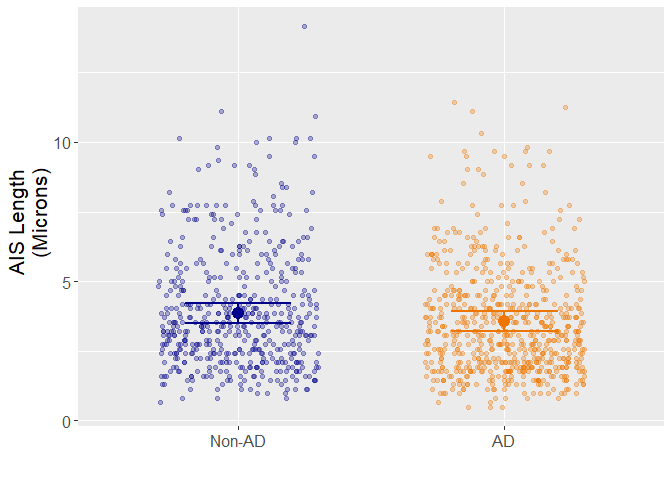

```r
lengthplotstatus <- maxdist %>%
  ggplot() +
  geom_jitter(aes(x = Status,
                 y = Dist,
                 color = Status),
             alpha = .3,
             width = .3) +
  geom_point(data = pred_mean_lengthmod_status,
                aes(x = Status,
                    y = predicted,
                    color = Status),
                size = 4) +
  geom_errorbar(data = pred_mean_lengthmod_status,
                aes(x = Status,
                    ymin = conf.low,
                    ymax = conf.high,
                    color = Status),
                width = .4,
                lwd = 1) +
  labs(y = "AIS Length  \n (Microns)", x = "") +
  scale_color_manual(values =  c("darkblue", "darkorange2")) +
  theme(legend.position = "none",
        axis.title = element_text(size = 16),
        axis.text = element_text(size = 12))
lengthplotstatus
```

```r
#ggsave(lengthplotstatus, filename = "Figures/human_length_status.png", width = 6, height = 4)
```

## FIGURE: AIS Length by Status and Tangle

Show jitter plus predicted mean and 95% CI with these colors.

```r
# return dataset of predicted mean +/- 95%CI
pred_mean_lengthmod <- ggeffect(maxdistmod, terms = c("Status", "Tangle")) %>%
  as_tibble() %>%
  rename(Status = x)

pred_mean_lengthmod
```

```
## # A tibble: 6 × 6
##   Status predicted std.error conf.low conf.high group
##   <fct>      <dbl>     <dbl>    <dbl>     <dbl> <fct>
## 1 Non-AD      4.06     0.200     3.67      4.46 none
## 2 AD          3.71     0.185     3.35      4.07 none
## 3 Non-AD      3.67     0.246     3.19      4.16 ta
## 4 AD          3.45     0.268     2.93      3.98 ta
## 5 Non-AD      2.58     0.715     1.18      3.98 tangle
## 6 AD          2.69     0.275     2.15      3.22 tangle
```

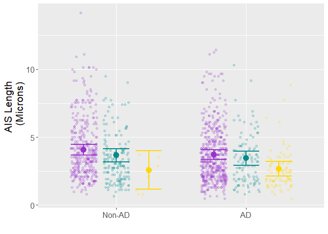

```r
lengthplot <- maxdist %>%
  ggplot() +
  geom_point(aes(x = Status,
                 y = Dist,
                 color = Tangle),
             position = position_jitterdodge(jitter.width = .2),
             alpha = .2) +
  geom_point(data = pred_mean_lengthmod,
                aes(x = Status,
                    y = predicted,
                    color = group),
                position = position_dodge(width = .75),
                size = 4) +
  geom_errorbar(data = pred_mean_lengthmod,
                aes(x = Status,
                    ymin = conf.low,
                    ymax = conf.high,
                    color = group),
                position = position_dodge(width = .75),
                width = .6,
                lwd = 1) +
  labs(y = "AIS Length \n (Microns)", x = "") +
  scale_color_manual(values =  c("darkorchid", "darkcyan", "gold")) +
  theme(legend.position = "none",
        axis.title = element_text(size= 16),
        axis.text = element_text(size = 12))

lengthplot
```

```r
#ggsave(lengthplot, filename = "Figures/human_length_status_tangle.png", width = 6, height = 4)
```

# Question 2 - Distribution of TRIM46 across distance

What does the TRIM46 fluorescence look like across the axon initial segment for AD v. non-AD neurons? Is the shape influenced by presence of tangles?

To show the shape of the TRIM46 intensity across distance, the raw data looked very messy. A rolling average across 3-distance observations works nicely to show the trend.

I used the `rollapply()` function rather than the more standard `rollmean()` function because `rollmean()` has no way to remove NAs.

```r
alldat <- alldat %>%
  group_by(Brain, Neuron) %>%
  mutate(roll_Intensity = rollapply(TRIM46_intensity, 3, mean, na.rm = TRUE, fill = NA)) %>%
  ungroup()
```

## FIGURE: Distance by Intensity for each brain

One line per brain, rolling average averaged over all neurons at a given dist.

The rolling average is the average of a 3-dist chunk.

```r
rollavgdat <- alldat %>%
  group_by(Status, Brain, Dist) %>%
  summarize(Mean_Intensity = mean(roll_Intensity, na.rm = TRUE),
            sd_Intensity = sd(roll_Intensity, na.rm = TRUE),
            n_neurons = n(),
            se_Intensity = sd_Intensity/sqrt(n_neurons))
```

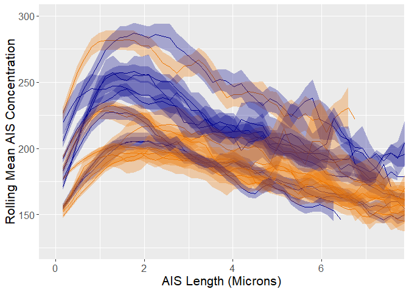

```r
lineplot <- rollavgdat %>%
  ggplot(aes(Dist, Mean_Intensity)) +
  geom_line(aes(group = Brain, color = Status)) +
  geom_ribbon(aes(ymin = Mean_Intensity-se_Intensity,
                  ymax = Mean_Intensity+se_Intensity,
                  group = Brain, fill = Status), alpha = .3) +
  scale_fill_manual(values = c("darkblue", "darkorange2")) +
  scale_color_manual(values = c("darkblue", "darkorange2")) +
  labs(y = "Rolling Mean AIS Concentration", x = "AIS Length (Microns)") +
  theme(legend.position = "none",
        axis.title = element_text(size = 16),
        axis.text = element_text(size =  12)) +
  coord_cartesian(xlim = c(0, 7.5),
                  ylim = c(125,300))

lineplot
```

```r
#ggsave(lineplot, filename = "Figures/human_lineplot_distVintensity.png", width =  6, height = 4)
```

Splines are a way to fit a non-linear curve to data to understand how the relationship between Distance and Intensity changes for Alz v. Normal and based on tangle status.

Try basic natural splines model with no interactions to just understand the splines portion of the model

```r
splinemod <- lmer(TRIM46_intensity ~ ns(Dist, df = 5) + Status + Tangle + (1|Brain), data = alldat)
```

Now try with interaction terms

```r
splinemod2 <- lmer(TRIM46_intensity ~ ns(Dist, df = 5)*Status + Status*Tangle + ns(Dist, df = 5)*Tangle + (1|Brain), data = alldat)
```

Compare splinemod1 and splinemod2

```r
anova(splinemod, splinemod2)
```

```
## refitting model(s) with ML (instead of REML)
```

```
## Data: alldat
## Models:
## splinemod: TRIM46_intensity ~ ns(Dist, df = 5) + Status + Tangle + (1 | Brain)
## splinemod2: TRIM46_intensity ~ ns(Dist, df = 5) * Status + Status * Tangle + ns(Dist, df = 5) * Tangle + (1 | Brain)
##            npar    AIC    BIC  logLik deviance  Chisq Df Pr(>Chisq)
## splinemod    11 287979 288069 -143978   287957
## splinemod2   28 287546 287776 -143745   287490 467.18 17  < 2.2e-16 ***
## ---
## Signif. codes:  0 '***' 0.001 '**' 0.01 '*' 0.05 '.' 0.1 ' ' 1
```

splinemod2 is better.

Try to simplify the model by removing the interaction of tangle and dist

```r
splinemod3 <- lmer(TRIM46_intensity ~ ns(Dist, df = 5)*Status + Status*Tangle + (1|Brain), data = alldat)
```

See if there is a difference in model fit between splinemod3 and splinemod2

```r
anova(splinemod2, splinemod3)
```

```
## refitting model(s) with ML (instead of REML)
```

```
## Data: alldat
## Models:
## splinemod3: TRIM46_intensity ~ ns(Dist, df = 5) * Status + Status * Tangle + (1 | Brain)
## splinemod2: TRIM46_intensity ~ ns(Dist, df = 5) * Status + Status * Tangle + ns(Dist, df = 5) * Tangle + (1 | Brain)
##            npar    AIC    BIC  logLik deviance  Chisq Df Pr(>Chisq)
## splinemod3   18 287626 287775 -143795   287590
## splinemod2   28 287546 287776 -143745   287490 100.86 10  < 2.2e-16 ***
## ---
## Signif. codes:  0 '***' 0.001 '**' 0.01 '*' 0.05 '.' 0.1 ' ' 1
```

splinemod2 fits better than splinemod3, so use that

```r
summary(splinemod2)
```

```
## Linear mixed model fit by REML. t-tests use Satterthwaite's method [
## lmerModLmerTest]
## Formula: TRIM46_intensity ~ ns(Dist, df = 5) * Status + Status * Tangle +
##     ns(Dist, df = 5) * Tangle + (1 | Brain)
##    Data: alldat
##
## REML criterion at convergence: 287371
##
## Scaled residuals:
##     Min      1Q  Median      3Q     Max
## -3.3197 -0.6383 -0.1099  0.4730 12.5693
##
## Random effects:
##  Groups   Name        Variance Std.Dev.
##  Brain    (Intercept)  579.6   24.08
##  Residual             1823.1   42.70
## Number of obs: 27780, groups:  Brain, 16
##
## Fixed effects:
##                                  Estimate Std. Error         df t value
## (Intercept)                      162.8714     8.6805    15.0638  18.763
## ns(Dist, df = 5)1                 83.6917     2.1377 27740.0276  39.151
## ns(Dist, df = 5)2                 63.0806     2.2300 27740.0710  28.287
## ns(Dist, df = 5)3                -28.5533     3.3613 27740.7223  -8.495
## ns(Dist, df = 5)4                 33.9968     5.3620 27740.9970   6.340
## ns(Dist, df = 5)5                -51.9338     8.0319 27741.0856  -6.466
## StatusAD                           3.7068    12.2185    14.7832   0.303
## Tangleta                          11.6806     2.6183 27753.9764   4.461
## Tangletangle                       0.9811     5.3381 27745.6134   0.184
## ns(Dist, df = 5)1:StatusAD       -29.8862     2.6512 27740.0288 -11.273
## ns(Dist, df = 5)2:StatusAD       -18.8716     2.8224 27740.0808  -6.686
## ns(Dist, df = 5)3:StatusAD        14.2739     4.8023 27740.6589   2.972
## ns(Dist, df = 5)4:StatusAD        -7.6481     7.5844 27740.7656  -1.008
## ns(Dist, df = 5)5:StatusAD         7.8479    12.9671 27740.8106   0.605
## StatusAD:Tangleta                -12.5302     1.6805 27706.3512  -7.456
## StatusAD:Tangletangle              1.8960     4.2952 27749.4450   0.441
## ns(Dist, df = 5)1:Tangleta        -3.1770     3.1698 27740.0134  -1.002
## ns(Dist, df = 5)2:Tangleta       -11.2710     3.4682 27740.0837  -3.250
## ns(Dist, df = 5)3:Tangleta        12.2471     6.9332 27740.2912   1.766
## ns(Dist, df = 5)4:Tangleta       -14.2708    12.2833 27740.4091  -1.162
```

[output cut: 20 more lines]

```
## ns(Dist, df = 5)5:StatusAD      0.54504
## StatusAD:Tangleta              9.16e-14 ***
## StatusAD:Tangletangle           0.65890
## ns(Dist, df = 5)1:Tangleta      0.31622
## ns(Dist, df = 5)2:Tangleta      0.00116 **
## ns(Dist, df = 5)3:Tangleta      0.07733 .
## ns(Dist, df = 5)4:Tangleta      0.24532
## ns(Dist, df = 5)5:Tangleta      0.23265
## ns(Dist, df = 5)1:Tangletangle 6.58e-08 ***
## ns(Dist, df = 5)2:Tangletangle 3.32e-07 ***
## ns(Dist, df = 5)3:Tangletangle  0.10509
## ns(Dist, df = 5)4:Tangletangle  0.27792
## ns(Dist, df = 5)5:Tangletangle  0.19672
## ---
## Signif. codes:  0 '***' 0.001 '**' 0.01 '*' 0.05 '.' 0.1 ' ' 1
```

```
##
## Correlation matrix not shown by default, as p = 26 > 12.
## Use print(x, correlation=TRUE)  or
##     vcov(x)        if you need it
```

```r
pairs(emmeans(splinemod2, specs = "Status"))
```

```
##  contrast      estimate   SE  df z.ratio p.value
##  (Non-AD) - AD     21.2 12.2 Inf   1.740  0.0818
##
## Results are averaged over the levels of: Tangle
## Degrees-of-freedom method: asymptotic
```

For all neurons, on average, AD neurons have intensity 21.2 lower than non-AD (p = 0.082)

See the difference between AD and non-AD for each level of tangle:

```r
pairs(emmeans(splinemod2, specs = "Status", by = "Tangle"))
```

```
## Tangle = none:
##  contrast      estimate   SE  df z.ratio p.value
##  (Non-AD) - AD     17.6 12.1 Inf   1.458  0.1449
##
## Tangle = ta:
##  contrast      estimate   SE  df z.ratio p.value
##  (Non-AD) - AD     30.2 12.1 Inf   2.482  0.0131
##
## Tangle = tangle:
##  contrast      estimate   SE  df z.ratio p.value
##  (Non-AD) - AD     15.7 12.8 Inf   1.231  0.2184
##
## Degrees-of-freedom method: asymptotic
```

- Within neurons with no tangle, AD neurons have intensity 17.6 lower than non-AD (p = 0.145)
- Within neurons with ta, AD neurons have intensity 30.2 lower than non-AD (p = 0.013)
- Within neurons with tangle, AD neurons have intensity 15.7 lower than non-AD (p = 0.218)

See the difference between tangle levels for each Status:

```r
pairs(emmeans(splinemod2, specs = "Tangle", by = "Status"))
```

```
## Note: D.f. calculations have been disabled because the number of observations exceeds 3000.
## To enable adjustments, add the argument 'pbkrtest.limit = 27780' (or larger)
## [or, globally, 'set emm_options(pbkrtest.limit = 27780)' or larger];
## but be warned that this may result in large computation time and memory use.
```

```
## Note: D.f. calculations have been disabled because the number of observations exceeds 3000.
## To enable adjustments, add the argument 'lmerTest.limit = 27780' (or larger)
## [or, globally, 'set emm_options(lmerTest.limit = 27780)' or larger];
## but be warned that this may result in large computation time and memory use.
```

```
## Status = Non-AD:
##  contrast      estimate   SE  df z.ratio p.value
##  none - ta        -3.36 1.62 Inf  -2.072  0.0956
##  none - tangle    27.97 4.53 Inf   6.180  <.0001
##  ta - tangle      31.33 4.56 Inf   6.869  <.0001
##
## Status = AD:
##  contrast      estimate   SE  df z.ratio p.value
##  none - ta         9.17 1.53 Inf   5.984  <.0001
##  none - tangle    26.07 2.48 Inf  10.513  <.0001
##  ta - tangle      16.90 2.70 Inf   6.257  <.0001
##
## Degrees-of-freedom method: asymptotic
## P value adjustment: tukey method for comparing a family of 3 estimates
```

- Within non-AD neurons:
  - ta have intensity 3.3 higher than none (p = 0.096)
  - tangles have intensity 27.97 lower than none (p < 0.0001)
  - tangles have intensity 31.33 lower than ta (p < 0.0001)
- Within AD neurons:
  - ta have intensity 9.17 lower than none (p < 0.0001)
  - tangles have intensity 26.07 lower than none (p < 0.0001)
  - tangles have intensity 16.90 lower than ta (p < 0.0001)

## FIGURE: Splines model plot

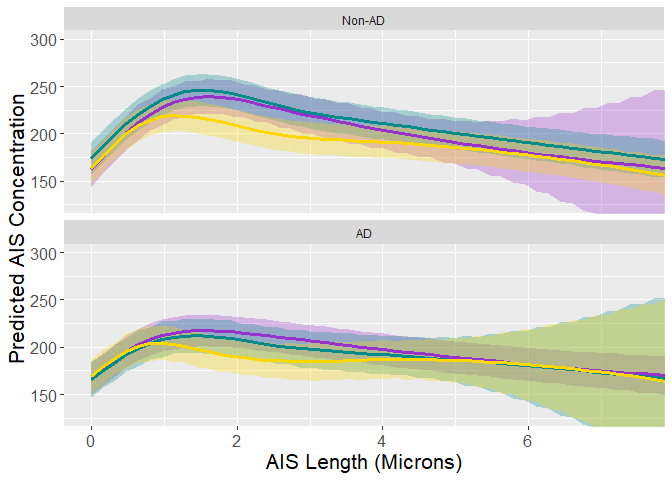

```r
splinesplot <- ggpredict(splinemod2, terms = c("Dist [all]", "Status", "Tangle")) %>%
  as_tibble() %>%
  rename(Dist = x,
         Status = group,
         Tangle = facet) %>%
  mutate(Tangle = factor(Tangle, levels = c("none", "ta", "tangle"))) %>%
  ggplot(aes(Dist, predicted, color = Tangle, fill = Tangle)) +
  facet_wrap(~Status, nrow = 2) +
  geom_ribbon(aes(ymin = conf.low,
                  ymax = conf.high),
              alpha = .3,
              color = NA) +
  geom_line(lwd = 1.25) +
  scale_color_manual(values = c("darkorchid", "darkcyan", "gold")) +
  scale_fill_manual(values = c("darkorchid", "darkcyan", "gold")) +
  labs(x = "AIS Length (Microns)",
       y = "Predicted AIS Concentration", color = "") +
  theme(legend.position = "none",
        axis.title = element_text(size = 16),
        axis.text = element_text(size = 12)) +
  coord_cartesian(ylim = c(125,300), xlim = c(0, 7.5))

splinesplot
```

```r
#ggsave(splinesplot, filename = "Figures/human_splines.png", width = 6, height = 4)
```

# Question 3 - Mean Intensity

3. Does mean AIS intensity at each distance differ between AD and non-AD neurons? Is the mean AIS intensity impacted by the presence of a tangle?

Create average intensity dataset. For each neuron, what is the average intensity across the whole distance that was measured

```r
avgint <- alldat %>%
  group_by(Status, Brain, Neuron, Tangle) %>%
  summarize(Mean_Intensity = mean(TRIM46_intensity),
            n = n()) %>%
  ungroup()
avgint
```

```
## # A tibble: 1,160 × 6
##    Status Brain  Neuron    Tangle Mean_Intensity     n
##    <fct>  <chr>  <chr>     <chr>           <dbl> <int>
##  1 Non-AD A14-13 Neuron 1  none             145.    26
##  2 Non-AD A14-13 Neuron 10 none             196.    20
##  3 Non-AD A14-13 Neuron 11 none             197.    26
##  4 Non-AD A14-13 Neuron 12 none             151.    12
##  5 Non-AD A14-13 Neuron 13 none             206.    38
##  6 Non-AD A14-13 Neuron 14 none             172.    21
##  7 Non-AD A14-13 Neuron 15 none             205.    34
##  8 Non-AD A14-13 Neuron 16 none             176.    24
##  9 Non-AD A14-13 Neuron 17 none             176.    24
## 10 Non-AD A14-13 Neuron 18 none             179.    17
## # … with 1,150 more rows
```

Model the mean intensity by Status and Tangle

```r
avgintmodB <- lmer(Mean_Intensity ~ Status * Tangle + (1|Brain), data = avgint)

summary(avgintmodB)
```

```
## Linear mixed model fit by REML. t-tests use Satterthwaite's method [
## lmerModLmerTest]
## Formula: Mean_Intensity ~ Status * Tangle + (1 | Brain)
##    Data: avgint
##
## REML criterion at convergence: 11241.8
##
## Scaled residuals:
##     Min      1Q  Median      3Q     Max
## -2.9697 -0.6795 -0.0915  0.5197  8.1270
##
## Random effects:
##  Groups   Name        Variance Std.Dev.
##  Brain    (Intercept) 620.2    24.90
##  Residual             929.4    30.49
## Number of obs: 1160, groups:  Brain, 16
##
## Fixed effects:
##                       Estimate Std. Error       df t value Pr(>|t|)
## (Intercept)            211.622      9.034   14.627  23.424 5.26e-13 ***
## StatusAD               -12.023     12.707   14.319  -0.946   0.3598
## Tangleta                 6.049      4.126 1145.267   1.466   0.1429
## Tangletangle           -16.957     11.283 1145.114  -1.503   0.1331
## StatusAD:Tangleta      -11.695      5.595 1153.681  -2.090   0.0368 *
## StatusAD:Tangletangle    7.312     11.945 1145.568   0.612   0.5406
## ---
## Signif. codes:  0 '***' 0.001 '**' 0.01 '*' 0.05 '.' 0.1 ' ' 1
##
## Correlation of Fixed Effects:
##               (Intr) SttsAD Tanglt Tngltn StatsAD:Tnglt
## StatusAD      -0.711
## Tangleta      -0.144  0.103
## Tangletangl   -0.047  0.034  0.213
## StatsAD:Tnglt  0.106 -0.107 -0.738 -0.157
## SttsAD:Tngltn  0.045 -0.047 -0.201 -0.945  0.218
```

Ignoring tangle, what is the average difference in mean intensity between AD and non-AD?

```r
pairs(emmeans(avgintmodB, specs = "Status"))
```

```
## NOTE: Results may be misleading due to involvement in interactions
```

```
##  contrast      estimate   SE   df t.ratio p.value
##  (Non-AD) - AD     13.5 13.2 16.7   1.022  0.3215
##
## Results are averaged over the levels of: Tangle
## Degrees-of-freedom method: kenward-roger
```

No difference

See pairwise comparisons within Status

```r
pairs(emmeans(avgintmodB, specs = "Tangle", by = "Status"))
```

```
## Status = Non-AD:
##  contrast      estimate    SE   df t.ratio p.value
##  none - ta        -6.05  4.14 1145  -1.461  0.3100
##  none - tangle    16.96 11.29 1145   1.502  0.2902
##  ta - tangle      23.01 11.16 1141   2.062  0.0983
##
## Status = AD:
##  contrast      estimate    SE   df t.ratio p.value
##  none - ta         5.65  3.78 1149   1.493  0.2945
##  none - tangle     9.65  3.93 1149   2.457  0.0377
##  ta - tangle       4.00  4.51 1141   0.886  0.6491
##
## Degrees-of-freedom method: kenward-roger
## P value adjustment: tukey method for comparing a family of 3 estimates
```

Within neurons with AD, those with tangles have mean intensity 9.65 lower than those without (p = 0.038)

See pairwise comparisons within Tangle level

```r
pairs(emmeans(avgintmodB, specs = "Status", by = "Tangle"))
```

```
## Tangle = none:
##  contrast      estimate   SE   df t.ratio p.value
##  (Non-AD) - AD    12.02 12.7 14.3   0.946  0.3598
##
## Tangle = ta:
##  contrast      estimate   SE   df t.ratio p.value
##  (Non-AD) - AD    23.72 13.3 17.3   1.780  0.0927
##
## Tangle = tangle:
##  contrast      estimate   SE   df t.ratio p.value
##  (Non-AD) - AD     4.71 17.0 45.7   0.277  0.7832
##
## Degrees-of-freedom method: kenward-roger
```

Within neurons with Tangles, those from AD brains have mean Intensity 4.7 lower than those from non-AD brains (p = 0.783)

## FIGURE: Mean Intensity by status

Each dot is an average of all of the intensity values for each neuron.

On top of dots are the predicted means and 95% confidence interval from the linear mixed model.

```r
# return dataset of predicted mean +/- 95%CI
pred_mean_avgintmod <- ggeffect(avgintmodB, terms = c("Status")) %>%
  as_tibble() %>%
  rename(Status = x)

pred_mean_avgintmod
```

```
## # A tibble: 2 × 6
##   Status predicted std.error conf.low conf.high group
##   <fct>      <dbl>     <dbl>    <dbl>     <dbl> <fct>
## 1 Non-AD      212.      8.97     194.      229. 1
## 2 AD          198.      8.91     180.      215. 1
```

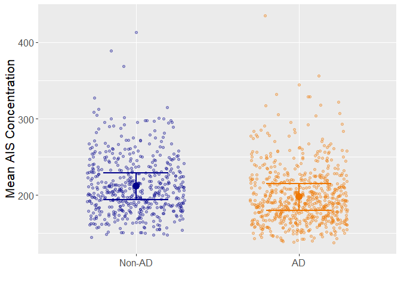

```r
meanint_supp_plot <- avgint %>%
  ggplot() +
  geom_jitter(aes(x = Status,
                 y = Mean_Intensity,
                 color = Status),
             alpha = .3,
             width = .3) +
  geom_point(data = pred_mean_avgintmod,
                aes(x = Status,
                    y = predicted,
                    color = Status),
                size = 4) +
  geom_errorbar(data = pred_mean_avgintmod,
                aes(x = Status,
                    ymin = conf.low,
                    ymax = conf.high,
                    color = Status),
                width = .4,
                lwd = 1) +
  labs(y = "Mean AIS Concentration", x = "") +
  scale_color_manual(values =  c("darkblue", "darkorange2")) +
  theme(legend.position = "none",
        axis.title = element_text(size = 16),
        axis.text = element_text(size = 12))

meanint_supp_plot
```

```r
#ggsave(meanint_supp_plot, filename = "Figures/human_meanintensity_status.png", width = 6, height = 4)
```

## FIGURE: Mean Intensity by Status and Tangle

Each dot is an average of all of the intensity values for each neuron.

Show jitter plus predicted mean and 95% CI with these colors.

```r
# return dataset of predicted mean +/- 95%CI
pred_mean_avgintmod <- ggeffect(avgintmodB, terms = c("Status", "Tangle")) %>%
  as_tibble() %>%
  rename(Status = x)

pred_mean_avgintmod
```

```
## # A tibble: 6 × 6
##   Status predicted std.error conf.low conf.high group
##   <fct>      <dbl>     <dbl>    <dbl>     <dbl> <fct>
## 1 Non-AD      212.      9.03     194.      229. none
## 2 AD          200.      8.94     182.      217. none
## 3 Non-AD      218.      9.37     199.      236. ta
## 4 AD          194.      9.47     175.      213. ta
## 5 Non-AD      195.     14.1      167.      222. tangle
## 6 AD          190.      9.51     171.      209. tangle
```

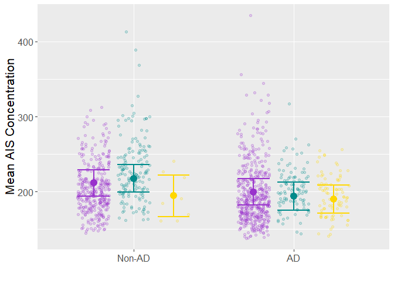

```r
meanintplot <- avgint %>%
  ggplot() +
  geom_point(aes(x = Status,
                 y = Mean_Intensity,
                 color = Tangle),
             position = position_jitterdodge(jitter.width = .2),
             alpha = .2) +
  geom_point(data = pred_mean_avgintmod,
                aes(x = Status,
                    y = predicted,
                    color = group),
                position = position_dodge(width = 0.75),
                size = 4) +
  geom_errorbar(data = pred_mean_avgintmod,
                aes(x = Status,
                    ymin = conf.low,
                    ymax = conf.high,
                    color = group),
                position = position_dodge(width = 0.75),
                width = .6,
                lwd = 1) +
  labs(y = "Mean AIS Concentration", x= "") +
  scale_color_manual(values =  c("darkorchid", "darkcyan", "gold")) +
  theme(legend.position = "none",
        axis.title = element_text(size = 16),
        axis.text = element_text(size = 12))

meanintplot
```

```r
#ggsave(meanintplot, filename = "Figures/human_meanintensity_status_tangle.png", width = 6, height = 4)
```

# Question 4 & 5 - Max and Min Intensity

Create max and min intensity variables

I tried the **raw** maximum and minimum intensities and determined that a smoothing function works better to establish the true max or min TRIM46 intensity across the distance of each neuron.

Therefore, I define the maximum and minimum intensity based on the rolling average Intensity for each neuron

```r
exint <- alldat %>%
  group_by(Brain, Neuron) %>%
  summarise(Max_intensity = max(roll_Intensity, na.rm = TRUE),
            Min_intensity = min(roll_Intensity, na.rm = TRUE))
```

Join the max and min intensity onto the alldat

```r
alldat <- alldat %>%
  left_join(exint, by = c("Brain", "Neuron"))
```

## Max intensity

Create dataset of just the max value for each neuron.

Check that each neuron only has one maximum

```r
alldat %>%
  filter(Max_intensity == roll_Intensity) %>%
  count(Brain, Neuron) %>%
  arrange(-n)
```

```
## # A tibble: 1,160 × 3
##    Brain   Neuron                n
##    <chr>   <chr>             <int>
##  1 A16-174 Neuron 62 (ta)        2
##  2 A11-30  Neuron 1 (tang)       1
##  3 A11-30  Neuron 10             1
##  4 A11-30  Neuron 100            1
##  5 A11-30  Neuron 101            1
##  6 A11-30  Neuron 102 (ta)       1
##  7 A11-30  Neuron 103 (tang)     1
##  8 A11-30  Neuron 104 (ta)       1
##  9 A11-30  Neuron 105 (ta)       1
## 10 A11-30  Neuron 106            1
## # … with 1,150 more rows
```

Hmm, one neuron has 2 maximums. Look at this neuron

```r
alldat %>%
  filter(Brain == "A16-174" & Neuron == "Neuron 62 (ta)")
```

```
## # A tibble: 19 × 9
##     Dist Status Brain   Neuron         TRIM46_i…¹ Tangle roll_…² Max_i…³ Min_i…⁴
##    <dbl> <fct>  <chr>   <chr>               <dbl> <chr>    <dbl>   <dbl>   <dbl>
##  1 0     Non-AD A16-174 Neuron 62 (ta)       242  ta         NA      379    192.
##  2 0.161 Non-AD A16-174 Neuron 62 (ta)       173  ta        203.     379    192.
##  3 0.322 Non-AD A16-174 Neuron 62 (ta)       195. ta        192.     379    192.
##  4 0.483 Non-AD A16-174 Neuron 62 (ta)       209  ta        208.     379    192.
##  5 0.644 Non-AD A16-174 Neuron 62 (ta)       220  ta        232.     379    192.
##  6 0.805 Non-AD A16-174 Neuron 62 (ta)       266  ta        261.     379    192.
##  7 0.966 Non-AD A16-174 Neuron 62 (ta)       296  ta        290      379    192.
##  8 1.13  Non-AD A16-174 Neuron 62 (ta)       308  ta        325.     379    192.
##  9 1.29  Non-AD A16-174 Neuron 62 (ta)       370. ta        350.     379    192.
## 10 1.45  Non-AD A16-174 Neuron 62 (ta)       372  ta        379      379    192.
## 11 1.61  Non-AD A16-174 Neuron 62 (ta)       395. ta        379      379    192.
## 12 1.77  Non-AD A16-174 Neuron 62 (ta)       370. ta        360      379    192.
## 13 1.93  Non-AD A16-174 Neuron 62 (ta)       315  ta        331.     379    192.
## 14 2.09  Non-AD A16-174 Neuron 62 (ta)       307. ta        299.     379    192.
## 15 2.25  Non-AD A16-174 Neuron 62 (ta)       274  ta        268.     379    192.
## 16 2.42  Non-AD A16-174 Neuron 62 (ta)       222  ta        239.     379    192.
## 17 2.58  Non-AD A16-174 Neuron 62 (ta)       222. ta        210.     379    192.
## 18 2.74  Non-AD A16-174 Neuron 62 (ta)       187  ta        207.     379    192.
## 19 2.90  Non-AD A16-174 Neuron 62 (ta)       211  ta         NA      379    192.
## # … with abbreviated variable names ¹TRIM46_intensity, ²roll_Intensity,
## #   ³Max_intensity, ⁴Min_intensity
```

Just preserve one of these datapoints, so that this neuron does not count twice

```r
maxint <- alldat %>%
  filter(Max_intensity == roll_Intensity) %>%
  filter(!(Brain == "A16-174" & Neuron == "Neuron 62 (ta)" & TRIM46_intensity == 372))

maxint
```

```
## # A tibble: 1,160 × 9
##     Dist Status Brain  Neuron            TRIM46…¹ Tangle roll_…² Max_i…³ Min_i…⁴
##    <dbl> <fct>  <chr>  <chr>                <dbl> <chr>    <dbl>   <dbl>   <dbl>
##  1 0.644 AD     A11-30 Neuron 1 (tang)       315. tangle    287.    287.    194.
##  2 0.966 AD     A11-30 Neuron 10             293. none      302.    302.    215.
##  3 3.06  AD     A11-30 Neuron 100            258. none      252.    252.    183.
##  4 1.93  AD     A11-30 Neuron 101            243. none      240.    240.    176.
##  5 1.61  AD     A11-30 Neuron 102 (ta)       180. ta        206.    206.    172.
##  6 1.13  AD     A11-30 Neuron 103 (tang)     220. tangle    222.    222.    191.
##  7 0.322 AD     A11-30 Neuron 104 (ta)       184  ta        197.    197.    155.
##  8 1.29  AD     A11-30 Neuron 105 (ta)       289. ta        260.    260.    192.
##  9 0.483 AD     A11-30 Neuron 106            199. none      227.    227.    207.
## 10 1.61  AD     A11-30 Neuron 107 (tang)     187. tangle    194.    194.    185.
## # … with 1,150 more rows, and abbreviated variable names ¹TRIM46_intensity,
## #   ²roll_Intensity, ³Max_intensity, ⁴Min_intensity
```

Each person contributes several max_intensity values (one from each neuron), so use linear mixed model

```r
maxmod <- lmer(Max_intensity ~ Status*Tangle + (1|Brain), data = maxint)
summary(maxmod)
```

```
## Linear mixed model fit by REML. t-tests use Satterthwaite's method [
## lmerModLmerTest]
## Formula: Max_intensity ~ Status * Tangle + (1 | Brain)
##    Data: maxint
##
## REML criterion at convergence: 12497.3
##
## Scaled residuals:
##     Min      1Q  Median      3Q     Max
## -2.5964 -0.6650 -0.1073  0.4496  8.5948
##
## Random effects:
##  Groups   Name        Variance Std.Dev.
##  Brain    (Intercept)  892.2   29.87
##  Residual             2782.5   52.75
## Number of obs: 1160, groups:  Brain, 16
##
## Fixed effects:
##                       Estimate Std. Error       df t value Pr(>|t|)
## (Intercept)            258.680     11.119   15.402  23.264 2.03e-13 ***
## StatusAD               -17.120     15.559   14.792  -1.100   0.2888
## Tangleta                 8.305      7.062 1069.691   1.176   0.2398
## Tangletangle           -34.151     19.497 1149.027  -1.752   0.0801 .
## StatusAD:Tangleta      -17.184      9.613 1131.439  -1.788   0.0741 .
## StatusAD:Tangletangle   14.407     20.640 1149.715   0.698   0.4853
## ---
## Signif. codes:  0 '***' 0.001 '**' 0.01 '*' 0.05 '.' 0.1 ' ' 1
##
## Correlation of Fixed Effects:
##               (Intr) SttsAD Tanglt Tngltn StatsAD:Tnglt
## StatusAD      -0.715
## Tangleta      -0.202  0.144
## Tangletangl   -0.066  0.047  0.209
## StatsAD:Tnglt  0.148 -0.151 -0.735 -0.154
## SttsAD:Tngltn  0.062 -0.066 -0.197 -0.945  0.214
```

- Compared to non-AD neurons, AD neurons have max intensity 17 lower (not sig)

Ignoring tangle, what is the average difference between AD and non-AD

```r
pairs(emmeans(maxmod, specs = "Status"))
```

```
## NOTE: Results may be misleading due to involvement in interactions
```

```
##  contrast      estimate   SE   df t.ratio p.value
##  (Non-AD) - AD       18 16.7 19.5   1.078  0.2941
##
## Results are averaged over the levels of: Tangle
## Degrees-of-freedom method: kenward-roger
```

See the pairwise differences within Status

```r
pairs(emmeans(maxmod, specs = "Tangle", by = "Status"))
```

```
## Status = Non-AD:
##  contrast      estimate    SE   df t.ratio p.value
##  none - ta        -8.31  7.10 1069  -1.169  0.4719
##  none - tangle    34.15 19.51 1149   1.750  0.1871
##  ta - tangle      42.46 19.30 1142   2.200  0.0717
##
## Status = AD:
##  contrast      estimate    SE   df t.ratio p.value
##  none - ta         8.88  6.53 1153   1.359  0.3627
##  none - tangle    19.74  6.78 1153   2.912  0.0102
##  ta - tangle      10.87  7.81 1143   1.392  0.3454
##
## Degrees-of-freedom method: kenward-roger
## P value adjustment: tukey method for comparing a family of 3 estimates
```

Within AD neurons, those with a tangle have max intensity 19.7 lower than those without (p = 0.010)

See the pairwise differences within Tangle level

```r
pairs(emmeans(maxmod, specs = "Status", by = "Tangle"))
```

```
## Tangle = none:
##  contrast      estimate   SE   df t.ratio p.value
##  (Non-AD) - AD    17.12 15.6 14.7   1.100  0.2890
##
## Tangle = ta:
##  contrast      estimate   SE   df t.ratio p.value
##  (Non-AD) - AD    34.30 17.0 20.7   2.015  0.0571
##
## Tangle = tangle:
##  contrast      estimate   SE   df t.ratio p.value
##  (Non-AD) - AD     2.71 25.0 93.7   0.108  0.9139
##
## Degrees-of-freedom method: kenward-roger
```

Within neurons with a tangle, those from AD brains have max intensity 2.7 lower than those from non-AD brains (p = ns)

## FIGURE: Max intensity by status

For each neuron, we calculated the maximum TRIM46 intensity value based on the 3-dist rolling average. Those maximum values are plotted here (each neuron contributes one datapoint)

On top of dots are the predicted means and 95% confidence interval from the linear mixed model.

```r
# return dataset of predicted mean +/- 95%CI
pred_mean_maxmod <- ggeffect(maxmod, terms = c("Status")) %>%
  as_tibble() %>%
  rename(Status = x)

pred_mean_maxmod
```

```
## # A tibble: 2 × 6
##   Status predicted std.error conf.low conf.high group
##   <fct>      <dbl>     <dbl>    <dbl>     <dbl> <fct>
## 1 Non-AD      258.      11.0     236.      279. 1
## 2 AD          238.      10.8     217.      259. 1
```

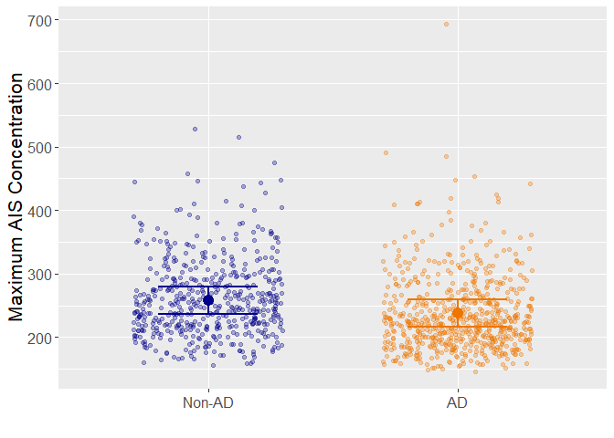

```r
maxint_supp_plot <- maxint %>%
  ggplot() +
  geom_jitter(aes(x = Status,
                 y = Max_intensity,
                 color = Status),
             alpha = .3,
             width = .3) +
  geom_point(data = pred_mean_maxmod,
                aes(x = Status,
                    y = predicted,
                    color = Status),
                size = 4) +
  geom_errorbar(data = pred_mean_maxmod,
                aes(x = Status,
                    ymin = conf.low,
                    ymax = conf.high,
                    color = Status),
                width = .4,
                lwd = 1) +
  labs(y = "Maximum AIS Concentration", x = "") +
  scale_color_manual(values =  c("darkblue", "darkorange2")) +
  theme(legend.position = "none",
        axis.title = element_text(size = 16),
        axis.text = element_text(size = 12))

maxint_supp_plot
```

```r
#ggsave(maxint_supp_plot, filename = "Figures/human_maxintensity_status.png", width = 6, height = 4)
```

## FIGURE: Max intensity by status and tangle

For each neuron, we calculated the maximum TRIM46 intensity value based on the 3-dist rolling average. Those maximum values are plotted here (each neuron contributes one datapoint)

On top of dots are the predicted means and 95% confidence interval from the linear mixed model.

```r
# return dataset of predicted mean +/- 95%CI
pred_mean_maxmod <- ggeffect(maxmod, terms = c("Status", "Tangle")) %>%
  as_tibble() %>%
  rename(Status = x)

pred_mean_maxmod
```

```
## # A tibble: 6 × 6
##   Status predicted std.error conf.low conf.high group
##   <fct>      <dbl>     <dbl>    <dbl>     <dbl> <fct>
## 1 Non-AD      259.      11.1     237.      280. none
## 2 AD          242.      10.9     220.      263. none
## 3 Non-AD      267.      11.9     244.      290. ta
## 4 AD          233.      12.1     209.      257. ta
## 5 Non-AD      225.      21.8     182.      267. tangle
## 6 AD          222.      12.3     198.      246. tangle
```

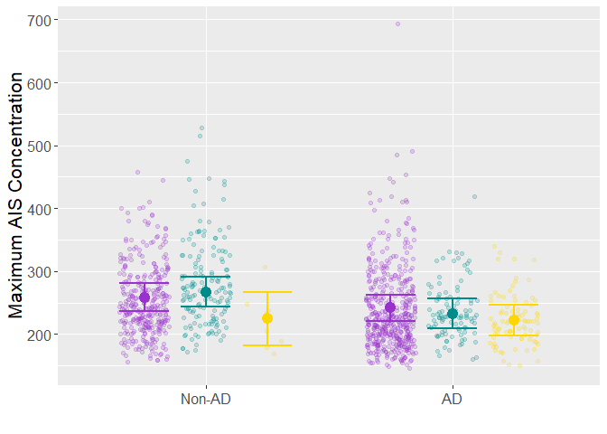

```r
maxintplot <- maxint %>%
  ggplot() +
  geom_point(aes(x = Status,
                 y = Max_intensity,
                 color = Tangle),
             position = position_jitterdodge(jitter.width = .2),
             alpha = .2) +
  geom_point(data = pred_mean_maxmod,
                aes(x = Status,
                    y = predicted,
                    color = group),
                position = position_dodge(width = .75),
                size = 4) +
  geom_errorbar(data = pred_mean_maxmod,
                aes(x = Status,
                    ymin = conf.low,
                    ymax = conf.high,
                    color = group),
                position = position_dodge(width = .75),
                width = .6,
                lwd = 1) +
  labs(y = "Maximum AIS Concentration", x = "") +
  scale_color_manual(values =  c("darkorchid", "darkcyan", "gold")) +
  theme(legend.position = "none",
        axis.title = element_text(size =16),
        axis.text = element_text(size = 12))

maxintplot
```

```r
#ggsave(maxintplot, filename = "Figures/human_maxintensity_status_tangle.png", width = 6, height = 4)
```

## Min intensity

Create dataset of just the min value for each neuron.

Check that each neuron only has one minimum

```r
alldat %>%
  filter(Min_intensity == roll_Intensity) %>%
  count(Brain, Neuron) %>%
  arrange(-n)
```

```
## # A tibble: 1,160 × 3
##    Brain  Neuron                n
##    <chr>  <chr>             <int>
##  1 A11-30 Neuron 1 (tang)       1
##  2 A11-30 Neuron 10             1
##  3 A11-30 Neuron 100            1
##  4 A11-30 Neuron 101            1
##  5 A11-30 Neuron 102 (ta)       1
##  6 A11-30 Neuron 103 (tang)     1
##  7 A11-30 Neuron 104 (ta)       1
##  8 A11-30 Neuron 105 (ta)       1
##  9 A11-30 Neuron 106            1
## 10 A11-30 Neuron 107 (tang)     1
## # … with 1,150 more rows
```

Good

```r
minint <- alldat %>%
  filter(Min_intensity == roll_Intensity)
```

Each person contributes several min_intensity values, so use linear mixed model

```r
minintmod <- lmer(Min_intensity ~ Status*Tangle + (1|Brain), data = minint)
summary(minintmod)
```

```
## Linear mixed model fit by REML. t-tests use Satterthwaite's method [
## lmerModLmerTest]
## Formula: Min_intensity ~ Status * Tangle + (1 | Brain)
##    Data: minint
##
## REML criterion at convergence: 10240.7
##
## Scaled residuals:
##     Min      1Q  Median      3Q     Max
## -2.6089 -0.5979 -0.1335  0.4896  7.3048
##
## Random effects:
##  Groups   Name        Variance Std.Dev.
##  Brain    (Intercept) 494.9    22.25
##  Residual             387.4    19.68
## Number of obs: 1160, groups:  Brain, 16
##
## Fixed effects:
##                       Estimate Std. Error       df t value Pr(>|t|)
## (Intercept)            171.104      7.973   14.243  21.460 3.01e-12 ***
## StatusAD                -6.330     11.243   14.079  -0.563    0.582
## Tangleta                 2.122      2.678 1153.971   0.792    0.428
## Tangletangle             1.355      7.288 1142.810   0.186    0.853
## StatusAD:Tangleta       -3.554      3.624 1151.880  -0.981    0.327
## StatusAD:Tangletangle   -4.044      7.717 1143.079  -0.524    0.600
## ---
## Signif. codes:  0 '***' 0.001 '**' 0.01 '*' 0.05 '.' 0.1 ' ' 1
##
## Correlation of Fixed Effects:
##               (Intr) SttsAD Tanglt Tngltn StatsAD:Tnglt
## StatusAD      -0.709
## Tangleta      -0.106  0.075
## Tangletangl   -0.035  0.025  0.215
## StatsAD:Tnglt  0.078 -0.079 -0.739 -0.159
## SttsAD:Tngltn  0.033 -0.035 -0.203 -0.944  0.220
```

AD neurons have min intensity 6.3 lower than non-AD neurons (p = ns)

Pairwise comparisons within Status

```r
pairs(emmeans(minintmod, specs = "Tangle", by = "Status"))
```

```
## Status = Non-AD:
##  contrast      estimate   SE   df t.ratio p.value
##  none - ta       -2.122 2.68 1154  -0.791  0.7086
##  none - tangle   -1.355 7.29 1143  -0.186  0.9811
##  ta - tangle      0.766 7.20 1141   0.106  0.9938
##
## Status = AD:
##  contrast      estimate   SE   df t.ratio p.value
##  none - ta        1.433 2.44 1145   0.587  0.8274
##  none - tangle    2.689 2.54 1145   1.060  0.5392
##  ta - tangle      1.256 2.91 1141   0.431  0.9027
##
## Degrees-of-freedom method: kenward-roger
## P value adjustment: tukey method for comparing a family of 3 estimates
```

No differences

Pairwise comparisons within Tangle levels

```r
pairs(emmeans(minintmod, specs = "Status", by = "Tangle"))
```

```
## Tangle = none:
##  contrast      estimate   SE   df t.ratio p.value
##  (Non-AD) - AD     6.33 11.2 14.2   0.563  0.5822
##
## Tangle = ta:
##  contrast      estimate   SE   df t.ratio p.value
##  (Non-AD) - AD     9.88 11.5 15.7   0.857  0.4046
##
## Tangle = tangle:
##  contrast      estimate   SE   df t.ratio p.value
##  (Non-AD) - AD    10.37 13.4 28.6   0.773  0.4457
##
## Degrees-of-freedom method: kenward-roger
```

No differences

## FIGURE: Min intensity by status

For each neuron, we calculated the minimum TRIM46 intensity value based on the 3-dist rolling average. Those values are plotted here (each neuron contributes one datapoint)

On top of dots are the predicted means and 95% confidence interval from the linear mixed model.

```r
# return dataset of predicted mean +/- 95%CI
pred_mean_minmod <- ggeffect(minintmod, terms = c("Status")) %>%
  as_tibble() %>%
  rename(Status = x)

pred_mean_minmod
```

```
## # A tibble: 2 × 6
##   Status predicted std.error conf.low conf.high group
##   <fct>      <dbl>     <dbl>    <dbl>     <dbl> <fct>
## 1 Non-AD      172.      7.94     156.      187. 1
## 2 AD          164.      7.92     149.      180. 1
```

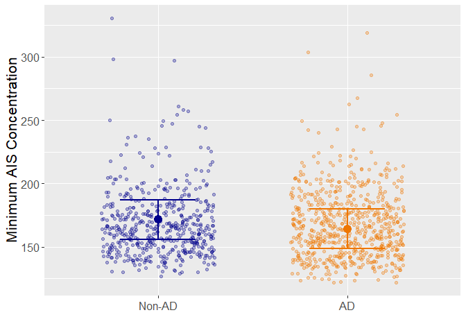

```r
minint_supp_plot <- minint %>%
  ggplot() +
  geom_jitter(aes(x = Status,
                 y = Min_intensity,
                 color = Status),
             alpha = .3,
             width = .3) +
  geom_point(data = pred_mean_minmod,
                aes(x = Status,
                    y = predicted,
                    color = Status),
                size = 4) +
  geom_errorbar(data = pred_mean_minmod,
                aes(x = Status,
                    ymin = conf.low,
                    ymax = conf.high,
                    color = Status),
                width = .4,
                lwd = 1) +
  labs(y = "Minimum AIS Concentration", x = "") +
  scale_color_manual(values =  c("darkblue", "darkorange2")) +
  theme(legend.position = "none",
        axis.title = element_text(size =16),
        axis.text = element_text(size = 12))

minint_supp_plot
```

```r
#ggsave(minint_supp_plot, filename = "Figures/human_minintensity_status.png", width = 6, height = 4)
```

## FIGURE: Min intensity by status and tangle

For each neuron, we calculated the minimum TRIM46 intensity value based on the 3-dist rolling average. Those values are plotted here (each neuron contributes one datapoint)

On top of dots are the predicted means and 95% confidence interval from the linear mixed model.

```r
# return dataset of predicted mean +/- 95%CI
pred_mean_minmod <- ggeffect(minintmod, terms = c("Status", "Tangle")) %>%
  as_tibble() %>%
  rename(Status = x)

pred_mean_minmod
```

```
## # A tibble: 6 × 6
##   Status predicted std.error conf.low conf.high group
##   <fct>      <dbl>     <dbl>    <dbl>     <dbl> <fct>
## 1 Non-AD      171.      7.97     155.      187. none
## 2 AD          165.      7.93     149.      180. none
## 3 Non-AD      173.      8.14     157.      189. ta
## 4 AD          163.      8.18     147.      179. ta
## 5 Non-AD      172.     10.6      152.      193. tangle
## 6 AD          162.      8.20     146.      178. tangle
```

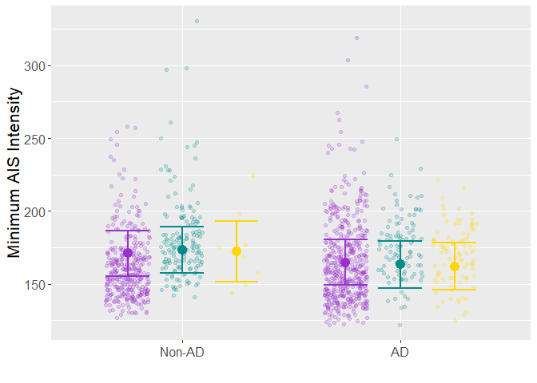

```r
minintplot <- minint %>%
  ggplot() +
  geom_point(aes(x = Status,
                 y = Min_intensity,
                 color = Tangle),
             position = position_jitterdodge(jitter.width = .2),
             alpha = .2) +
  geom_point(data = pred_mean_minmod,
                aes(x = Status,
                    y = predicted,
                    color = group),
                position = position_dodge(width = .75),
                size = 4) +
  geom_errorbar(data = pred_mean_minmod,
                aes(x = Status,
                    ymin = conf.low,
                    ymax = conf.high,
                    color = group),
                position = position_dodge(width = .75),
                width = .6,
                lwd = 1) +
  labs(y = "Minimum AIS Intensity", x = "") +
  scale_color_manual(values =  c("darkorchid", "darkcyan", "gold")) +
  theme(legend.position = "none",
        axis.title = element_text(size =16),
        axis.text = element_text(size = 12))

minintplot
```

```r
#ggsave(minintplot, filename = "Figures/human_minintensity_status_tangle.png", width = 6, height = 4)
```

# Question 6 - AD only Length by severity of disease

6. Within Alzheimer’s brains, is there a difference in AIS length across severity of disease?

First create dataset of AIS lengths for only the AD neurons

```r
ADlength <- maxdist %>%
  filter(Status == "AD")
```

Then add a variable for disease severity: - least severe: AD 1 (A16-109), AD 3 (A15-217) - moderate severity: AD 2 (A15-93), AD 5 (A11-84), AD 7 (A15-167_) - most severe: AD 4 (A13-66), AD 6 (A16-214), AD 8 (A11-30)

```r
ADlength <- ADlength %>%
  mutate(Stage = case_when(Brain == "A16-109" |
                             Brain == "A15-217" ~ "Least Severe",
                           Brain == "A15-93" |
                             Brain == "A11-84" |
                             Brain == "A15-167_" ~ "Moderate Severity",
                           Brain == "A13-66" |
                             Brain == "A16-214" |
                             Brain == "A11-30" ~ "Most Severe"))
```

Exploratory plots

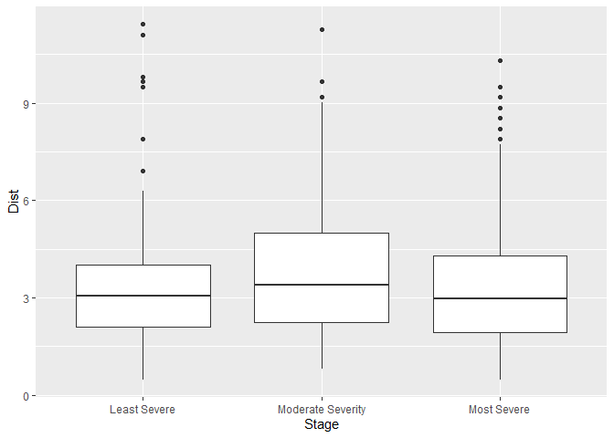

```r
ADlength %>%
  ggplot(aes(Stage, Dist)) +
  geom_boxplot()
```

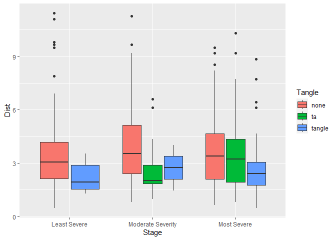

```r
# add tangle
ADlength %>%
  ggplot(aes(Stage, Dist, fill = Tangle)) +
  geom_boxplot()
```

Model with Tangle

```r
adlengthmod <- lmer(Dist ~ Stage*Tangle + (1|Brain), data = ADlength)
```

```
## fixed-effect model matrix is rank deficient so dropping 1 column / coefficient
```

```r
summary(adlengthmod)
```

```
## Linear mixed model fit by REML. t-tests use Satterthwaite's method [
## lmerModLmerTest]
## Formula: Dist ~ Stage * Tangle + (1 | Brain)
##    Data: ADlength
##
## REML criterion at convergence: 2688
##
## Scaled residuals:
##     Min      1Q  Median      3Q     Max
## -1.8080 -0.7277 -0.1553  0.5029  4.1326
##
## Random effects:
##  Groups   Name        Variance Std.Dev.
##  Brain    (Intercept) 0.1689   0.411
##  Residual             3.4813   1.866
## Number of obs: 657, groups:  Brain, 8
##
## Fixed effects:
##                                      Estimate Std. Error        df t value
## (Intercept)                           3.44335    0.33379   4.73345  10.316
## StageModerate Severity                0.48973    0.43544   4.93221   1.125
## StageMost Severe                      0.23121    0.44027   5.04623   0.525
## Tangleta                             -0.16493    0.25422 641.16528  -0.649
## Tangletangle                         -0.94477    0.63192 636.60151  -1.495
## StageModerate Severity:Tangleta      -0.64573    0.62392 645.03257  -1.035
## StageModerate Severity:Tangletangle   0.25935    1.48081 648.92566   0.175
## StageMost Severe:Tangletangle        -0.06322    0.68562 638.62513  -0.092
##                                     Pr(>|t|)
## (Intercept)                         0.000201 ***
## StageModerate Severity              0.312462
## StageMost Severe                    0.621729
## Tangleta                            0.516721
## Tangletangle                        0.135392
## StageModerate Severity:Tangleta     0.301079
## StageModerate Severity:Tangletangle 0.861026
## StageMost Severe:Tangletangle       0.926556
## ---
## Signif. codes:  0 '***' 0.001 '**' 0.01 '*' 0.05 '.' 0.1 ' ' 1
##
## Correlation of Fixed Effects:
##                     (Intr) StgMdS StgMsS Tanglt Tngltn StagMdrtSvrty:Tnglt
## StgMdrtSvrt         -0.767
## StageMstSvr         -0.758  0.581
## Tangleta             0.000  0.000 -0.202
## Tangletangl         -0.137  0.105  0.104  0.000
## StagMdrtSvrty:Tnglt  0.000 -0.082  0.082 -0.407  0.000
## StgMdrtSvrty:Tngltn  0.058 -0.079 -0.044  0.000 -0.427  0.045
## StgMstSvr:T          0.126 -0.097 -0.175  0.141 -0.922 -0.057
##                     StgMdrtSvrty:Tngltn
## StgMdrtSvrt
## StageMstSvr
## Tangleta
## Tangletangl
## StagMdrtSvrty:Tnglt
## StgMdrtSvrty:Tngltn
## StgMstSvr:T          0.393
## fit warnings:
## fixed-effect model matrix is rank deficient so dropping 1 column / coefficient
```

No differences

# Question 7 - AD only AIS intensity by severity

7. Within Alzheimer’s brains, is there a difference in AIS intensity across severity of disease?
1. Splines
2. Mean
3. Max

## Question 7a - Splines for intensity by severity

First create a dataset of all the distances for only AD brains and then add the severity to the dataset.

```r
ADdat <- alldat %>%
  filter(Status == "AD") %>%
  mutate(Stage = case_when(Brain == "A16-109" |
                             Brain == "A15-217" ~ "Least Severe",
                           Brain == "A15-93" |
                             Brain == "A11-84" |
                             Brain == "A15-167_" ~ "Moderate Severity",
                           Brain == "A13-66" |
                             Brain == "A16-214" |
                             Brain == "A11-30" ~ "Most Severe"))
```

Plot

One line per brain, rolling average averaged over all neurons at a given dist. Then color by Stage.

The rolling average is the average of a 3-dist chunk.

```r
rollavgdat <- ADdat %>%
  group_by(Brain, Stage, Dist) %>%
  summarize(Mean_Intensity = mean(roll_Intensity, na.rm = TRUE),
            sd_Intensity = sd(roll_Intensity, na.rm = TRUE),
            n_neurons = n(),
            se_Intensity = sd_Intensity/sqrt(n_neurons))
```

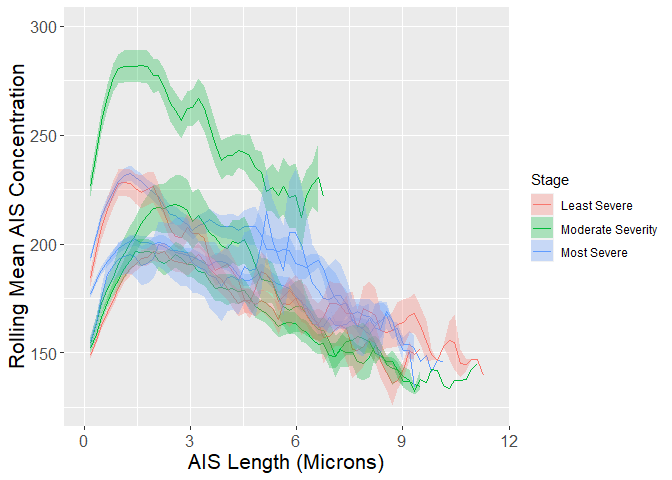

```r
lineplot <- rollavgdat %>%
  ggplot(aes(Dist, Mean_Intensity)) +
  geom_line(aes(group = Brain, color = Stage)) +
  geom_ribbon(aes(ymin = Mean_Intensity-se_Intensity,
                  ymax = Mean_Intensity+se_Intensity,
                  group = Brain, fill = Stage), alpha = .3) +
  labs(y = "Rolling Mean AIS Concentration", x = "AIS Length (Microns)") +
  theme(axis.title = element_text(size = 16),
        axis.text = element_text(size =  12)) +
  coord_cartesian(ylim = c(125,300))

lineplot
```

No modeling needed because there does not seem to be a trend

## Question 7b - Mean intensity by severity

Start with avgint dataset from above. Filter for AD and add severity variable

```r
ADavg <- avgint %>%
  filter(Status == "AD") %>%
  mutate(Stage = case_when(Brain == "A16-109" |
                             Brain == "A15-217" ~ "Least Severe",
                           Brain == "A15-93" |
                             Brain == "A11-84" |
                             Brain == "A15-167_" ~ "Moderate Severity",
                           Brain == "A13-66" |
                             Brain == "A16-214" |
                             Brain == "A11-30" ~ "Most Severe"))
```

Exploratory plot

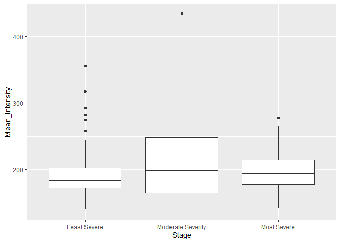

```r
ADavg %>%
  ggplot(aes(Stage, Mean_Intensity)) +
  geom_boxplot()
```

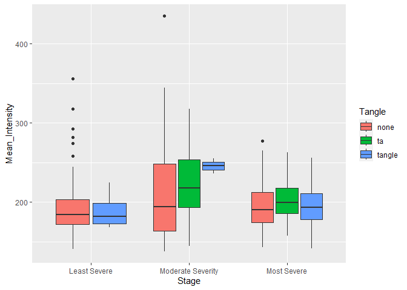

```r
# add tangle
ADavg %>%
  ggplot(aes(Stage, Mean_Intensity, fill = Tangle)) +
  geom_boxplot()
```

## Question 7c - Max intensity by severity

Start with maxint dataset from above. Filter for AD and add severity variable

```r
ADmax <- maxint %>%
  filter(Status == "AD") %>%
  mutate(Stage = case_when(Brain == "A16-109" |
                             Brain == "A15-217" ~ "Least Severe",
                           Brain == "A15-93" |
                             Brain == "A11-84" |
                             Brain == "A15-167_" ~ "Moderate Severity",
                           Brain == "A13-66" |
                             Brain == "A16-214" |
                             Brain == "A11-30" ~ "Most Severe"))
```

Exploratory plot

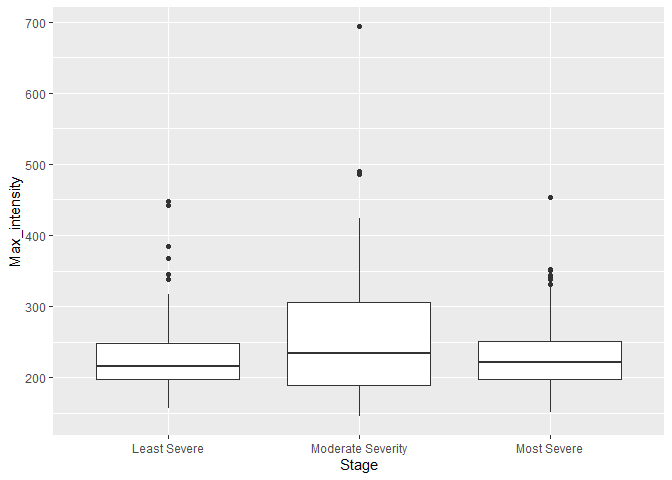

```r
ADmax %>%
  ggplot(aes(Stage, Max_intensity)) +
  geom_boxplot()
```

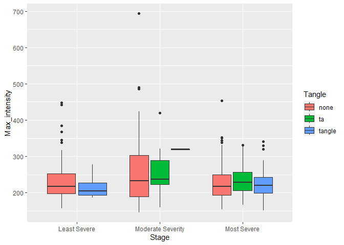

```r
# add tangle
ADmax %>%
  ggplot(aes(Stage, Max_intensity, fill = Tangle)) +
  geom_boxplot()
```

No trend seen here either.